# Data integration

Maksim Kholmatov

## Introduction

This vignette will demonstrate how to combine separate datasets containing single-cell chromatin data. This is a common task that arises in cases when:

- You have too many cells to fit into a single lane of the 10x chip.
- You produce libraries on multiple days.
- You want to integrate your data with public datasets (to increase statistical power or improve cell type annotations).

## References

This vignette is a based on [this](https://satijalab.org/signac/articles/integrate_atac.html) and [this](https://satijalab.org/signac/articles/merging.html) vignettes for the Signac package with some explanations borrowed from the [ArchR documentation](https://www.archrproject.com/bookdown/).

## Load required R libraries

Before we start with any analysis, it is good practice to load all required libraries. This will also immediately identify libraries that may be missing. Note that for this course, we pre-installed all libraries for you. When you run your own analysis, you have to check which libraries are already available, and which are not. We use `suppressPackageStartupMessages` here to suppress the output messages of the various packages for reasons of brevity.

In order to control the computing resource allocation we will explicitly load the `future` package and set the required parameters.

When using functions that sample pseudorandom numbers, each time you execute them you will obtain a different result. For the purpose of this vignette, this is not what we want. We therefore set a particular seed value(here: 1990) so that the result will always be the same. For more information, check out [this webpage](https://r-coder.com/set-seed-r) that explains this general concept in more detail.

```r
suppressPackageStartupMessages({
library(Seurat)
library(Signac)
library(tidyverse)
library(GenomicRanges)
library(future)
})

# parallelization parameters
plan("multisession", workers = 8) # number of parallel workers for functions that support it
options(future.globals.maxSize = 40000 * 1024^2) # RAM limit of 40 Gb

set.seed(1990)
```

## Create Seurat object from multiple datasets

### Create consensus peak set

When merging multiple single-cell chromatin datasets, it’s important to be aware that if peak calling was performed on each dataset independently, the peaks are unlikely to be exactly the same. We therefore need to create a common set of peaks across all the datasets to be merged.

There are multiple ways to combine different peak sets with different pros and cons. Here is a couple of options:

- **Raw peak overlap**: Raw peak overlap involves taking any peaks that overlap each other and merging these into a single larger peak. In this scheme, daisy-chaining can become a problem because peaks that don’t directly overlap each other get included in the same larger peak because they are bridged by a shared internal peak. Another problem with this type of approach is that, if you want to keep track of peak summits, you are forced to either pick a single new summit for each new merged peak or keep track of all of the summits that apply to each new merged peak.

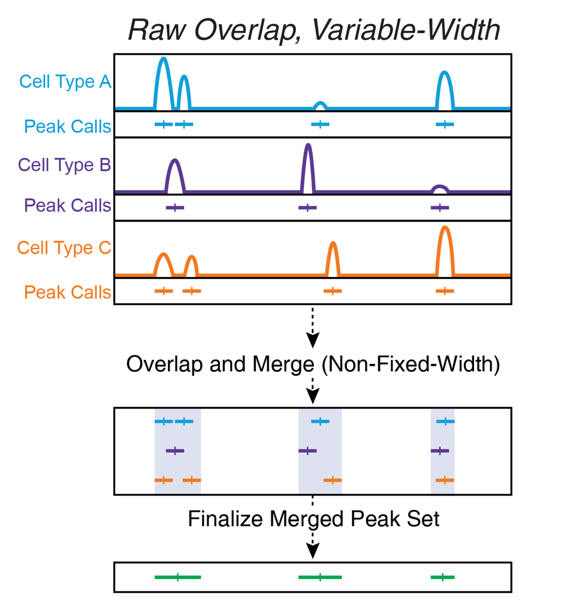

- **Clustered Overlap**: Clustered overlap takes peaks that cluster together and picks a single winner. This is done by keeping the most significant peak in each cluster. This may end up under-calling peaks and missing smaller peaks located nearby.

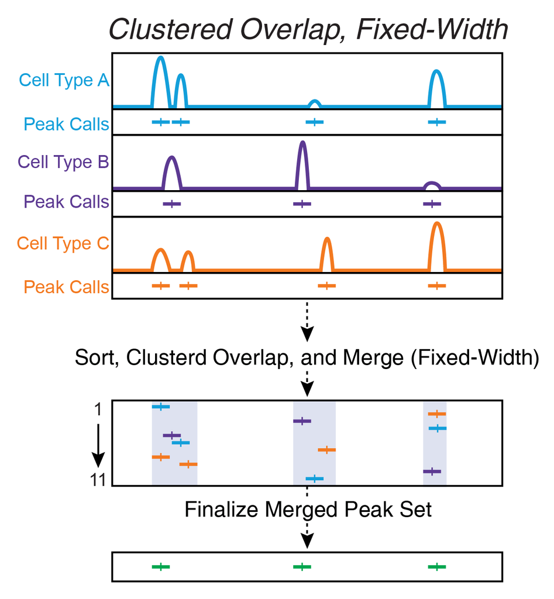

- **Iterative Overlap**: [Iterative overlap removal](https://www.science.org/doi/10.1126/science.aav1898) is the method used in the [ArchR](https://www.archrproject.com/bookdown/the-iterative-overlap-peak-merging-procedure.html) package. It avoids the issues mentioned above. Peaks are first ranked by their significance. The most significant peak is retained and any peak that directly overlaps with the most significant peak is removed from further analysis. Then, of the remaining peaks, this process is repeated until no more peaks exist. This avoids daisy-chaining and still allows for use of fixed-width peaks.

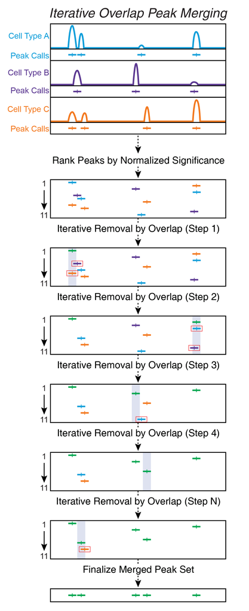

Here is the comparisons of results of all 3 methods for the peaks from above.

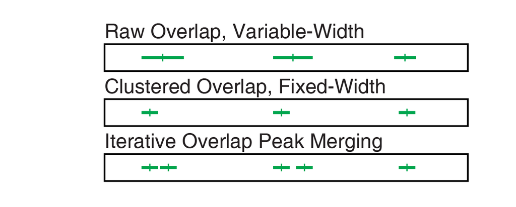

They all produce distinct sets of peaks, and the **Iterative Overlap** is argued by the authors of ArchR to be the most optimal. However in our analysis we will stick with the **Raw Overlap** method for the sake of simplicity and because it is still widely used.

To create a unified set of peaks we can use functions from the `GenomicRanges` package. The `reduce` function from `GenomicRanges` will merge all intersecting peaks.

```r
# Make sure to have a trailing slash here
outFolder="/home/max/Work/EMBL/PROJECTS/atac-seq_course_2022/data/"
sample1Folder = paste0(outFolder, "samples/Subsample01Seed1/")
sample2Folder = paste0(outFolder, "samples/Subsample01Seed2/")
sample3Folder = paste0(outFolder, "samples/Subsample01Seed3/")


# read BED files containing sample-specific peaks as a data.frame
peaks.1 = read.table(
  file = paste0(sample1Folder, "peaks.bed"),
  skip = 52,
  col.names = c("chr", "start", "end")
)
peaks.2 = read.table(
  file = paste0(sample2Folder, "peaks.bed"),
  skip = 52,
  col.names = c("chr", "start", "end")
)
peaks.3 = read.table(
  file = paste0(sample3Folder, "peaks.bed"),
  skip = 52,
  col.names = c("chr", "start", "end")
)

head(peaks.1)
```

Now we can use these data.frames to create `GenomicRanges` objects for each peak set.

```r
# convert data frames to GenomicRanges
gr.1 = makeGRangesFromDataFrame(peaks.1)
gr.2 = makeGRangesFromDataFrame(peaks.2)
gr.3 = makeGRangesFromDataFrame(peaks.3)

rm(peaks.1, peaks.2, peaks.3)

gr.1
```

Now we can combine the ranges into a single peak set.

```r
# Create a unified set of peaks to quantify in each dataset
combined.peaks = reduce(x = c(gr.1, gr.2, gr.3))
```

If you are concerned about potential drawbacks of using **Raw Overlap** peak merging strategy, we can check how it affects the distribution of peak widths.

```r
peak_widths = rbind(
  tibble(PeakWidth = width(combined.peaks), PeakSet="Combined"),
  tibble(PeakWidth = width(gr.1), PeakSet="Sample1"),
  tibble(PeakWidth = width(gr.2), PeakSet="Sample2"),
  tibble(PeakWidth = width(gr.3), PeakSet="Sample3")
  )

ggplot(data = peak_widths, aes(x = PeakWidth, col = PeakSet))+
  geom_density()+
  ggtitle("Distribution of peak widths in each sample and in consensus peak set")
```

[output not shown]

```r
peak_widths %>%
  group_by(PeakSet) %>%
  slice_max(n=10, order_by=PeakWidth) %>%
  mutate(rank = 1:10) %>%
  pivot_wider(names_from = PeakSet, values_from = PeakWidth, id_cols = rank)
```

```r
peak_widths %>%
  group_by(PeakSet) %>%
  slice_min(n=10, order_by=PeakWidth) %>%
  mutate(rank = 1:10) %>%
  pivot_wider(names_from = PeakSet, values_from = PeakWidth, id_cols = rank)
```

If there are any anomalous peaks that arise from the merging we can filter them out. Additionally we can remove all non-standard chromosomes.

```r
# Filter out bad peaks based on length
peakwidths = width(combined.peaks)
combined.peaks = combined.peaks[peakwidths  < 10000 & peakwidths > 20]

# might as well filter out non-standard chromosomes
seqlevels(combined.peaks, pruning.mode="coarse") = standardChromosomes(combined.peaks)

combined.peaks
```

### Create Fragment objects

To quantify our combined set of peaks we’ll need to create a `Fragment` object for each experiment. The `Fragment` class is a specialized class defined in Signac to hold all the information related to a single fragment file.

#### Reading and filtering the cell/barcode metadata

First we’ll load the cell metadata for each experiment so that we know what cell barcodes are contained in each file

```r
# load metadata
md.1 = read.table(
  file = paste0(sample1Folder, "singlecell.csv"),
  stringsAsFactors = FALSE,
  sep = ",",
  header = TRUE,
  row.names = 1
)[-1, ] # remove the first row

md.2 = read.table(
  file = paste0(sample2Folder, "singlecell.csv"),
  stringsAsFactors = FALSE,
  sep = ",",
  header = TRUE,
  row.names = 1
)[-1, ] # remove the first row

md.3 = read.table(
  file = paste0(sample3Folder, "singlecell.csv"),
  stringsAsFactors = FALSE,
  sep = ",",
  header = TRUE,
  row.names = 1
)[-1, ] # remove the first row
```

Now we can filter out non-cells and low quality cells. `singlecell.csv` metadata file already has quite a lot of QC information similar to what you produced in the `QClustering` vignette. You can check all of the options available [here](https://support.10xgenomics.com/single-cell-atac/software/pipelines/latest/output/singlecell), but for simplicity we will just use 2 of the available parameters:

- **is_cell_barcode**: binary indicator of whether barcode is associated with a cell according to cellranger’s automated cell calling algorithm.
- **passed_filters**: number of non-duplicate, usable read-pairs i.e. “fragments”.

```r
# perform an initial filtering of low count cells and non-cells
md.1 = md.1[as.logical(md.1$is__cell_barcode) & (md.1$passed_filters > 1000), ]
md.2 = md.2[as.logical(md.2$is__cell_barcode) & (md.2$passed_filters > 1000), ]
md.3 = md.3[as.logical(md.3$is__cell_barcode) & (md.3$passed_filters > 1000), ]
# As a side note. The cellranger-atac version 2.0 that we ran during testing
# produced a singlecell.csv file with the `is__cell_barcode` column spelled with
# a double underscore. This is probably an innocent bug, that would be fixed
# in later versions.
```

Alternatively to the last step we could have used the Seurat objects that you have created already in the `QClustering` vignette to extract high quality cells since it involved more thorough quality controls:

```r
# read the cell names from the filtered seurat objects
cells_from_seurat_sample1 = readRDS(file = paste0(sample1Folder, "obj.filt.rds")) %>%  colnames()
cells_from_seurat_sample2 = readRDS(file = paste0(sample2Folder, "obj.filt.rds")) %>%  colnames()
cells_from_seurat_sample3 = readRDS(file = paste0(sample3Folder, "obj.filt.rds")) %>%  colnames()

md.1 = md.1[cells_from_seurat_sample1, ]
md.2 = md.2[cells_from_seurat_sample2, ]
md.3 = md.3[cells_from_seurat_sample3, ]
```

#### Creating the fragment objects

Now we can create `Fragment` objects using the `CreateFragmentObject` function. The `CreateFragmentObject` function performs some checks to ensure that the file is present on disk and that it is compressed and indexed, computes the MD5 sum for the file and the tabix index so that we can tell if the file is modified at any point, and checks that the expected cells are present in the file.

```r
frags.1 = CreateFragmentObject(
  path = paste0(sample1Folder, "fragments.tsv.gz"),
  cells = rownames(md.1)
)
frags.2 = CreateFragmentObject(
  path = paste0(sample2Folder, "fragments.tsv.gz"),
  cells = rownames(md.2)
)
frags.3 = CreateFragmentObject(
  path = paste0(sample3Folder, "fragments.tsv.gz"),
  cells = rownames(md.3)
)
```

### Quantify peaks in each dataset

We can now create a matrix of peaks x cell for each sample using the `FeatureMatrix` function. This function is parallelized using the `future` package.

```r
sample1.counts = FeatureMatrix(
  fragments = frags.1,
  features = combined.peaks,
  cells = rownames(md.1)
)
sample2.counts = FeatureMatrix(
  fragments = frags.2,
  features = combined.peaks,
  cells = rownames(md.2)
)
sample3.counts = FeatureMatrix(
  fragments = frags.3,
  features = combined.peaks,
  cells = rownames(md.3)
)
```

### Create Seurat objects

We will now use the quantified matrices to create a Seurat object for each dataset, storing the Fragment object for each dataset in the assay.

```r
# First we create a ChromatinAssay object
sample1_assay = CreateChromatinAssay(
  sample1.counts,
  fragments = frags.1
)
# Then we create a Seurat object based on this ChromatinAssay
sample1 = CreateSeuratObject(
  sample1_assay,
  assay = "ATAC",
  project = "mouse_ES_LIF",
  meta.data=md.1
)

# First we create a ChromatinAssay object
sample2_assay = CreateChromatinAssay(
  sample2.counts,
  fragments = frags.2
)
# Then we create a Seurat object based on this ChromatinAssay
sample2 = CreateSeuratObject(
  sample2_assay,
  assay = "ATAC",
  project = "mouse_ES_LIF",
  meta.data=md.2
)

# First we create a ChromatinAssay object
sample3_assay = CreateChromatinAssay(
  sample3.counts,
  fragments = frags.3
)
# Then we create a Seurat object based on this ChromatinAssay
sample3 = CreateSeuratObject(
  sample3_assay,
  assay = "ATAC",
  project = "mouse_ES_LIF",
  meta.data=md.3
)
```

### Merge Seurat objects

Now that the objects each contain an assay with the same set of features, we can use the standard `merge` function to merge the objects. This will also merge all the fragment objects so that we retain the fragment information for each cell in the final merged object.

```r
# add information to identify dataset of origin
sample1$dataset = 'sample1'
sample2$dataset = 'sample2'
sample3$dataset = 'sample3'


# merge all datasets, adding a cell ID to make sure cell names are unique
combined = merge(
  x = sample1,
  y = list(sample2, sample3),
  add.cell.ids = c("1", "2", "3")
)

#Since we renamed corresponding cells in the combined object we should also rename them in separate ones.
sample1 = RenameCells(sample1, add.cell.id = "1")
sample2 = RenameCells(sample2, add.cell.id = "2")
sample3 = RenameCells(sample3, add.cell.id = "3")


combined
```

## Validate our integration

We finally have our combined object. Now we can perform standard pre-processing, keeping track of each cell’s dataset of origin. We can check for any batch effects visually on a UMAP plot.

```r
# Perform variable feature selection, data normalization, PCA and
# UMAP embedding into a 2D space.
combined = FindTopFeatures(combined, min.cutoff = 20)
combined = RunTFIDF(combined)
combined = RunSVD(combined)
combined = RunUMAP(combined, dims = 2:50, reduction = 'lsi', verbose = F)

# Plot the resulting UMAP colored by the original dataset of each cell.
DimPlot(combined, group.by = 'dataset', pt.size = 0.5)
```

[output not shown]

The merged object contains all fragment objects, and contains an internal mapping of cell names in the object to the cell names in each fragment file so that we can retrieve information from the files without having to change the cell names in each fragment file. We can check that functions that pull data from the fragment files work as expected on the merged object by plotting a region of the genome. Here we can can also check for any significant differences between datasets/batches, although it may depend heavily on the genomice region in question.

```r
CoveragePlot(
  object = combined,
  group.by = 'dataset',
  region = "chr1-19230000-19240000"
)
```

[output not shown]

Depending on the results of this section we may or may not need to perform further steps in order to mitigate any systematic batch effects between your samples. Whether or not this is needed you can gauge by how much sample dependent clustering is present in your merged object. If the cells from different datasets are more or less evenly distributed across your UMAP plot you can assume that there is no major batch effect that needs correcting. If the cells cluster primarily based on the dataset or within each cell type-specific cluster they further subcluster based on the initial dataset you probably need to correct this dataset-specific variation in order to avoid any downstream artefacts stemming from this dataset-specific variation.

**P.S.**: One special case you need to keep in mind in your analyses is when you observe a cluster that fully or mostly corresponds to one dataset, but you don’t observe similar imbalance in other clusters. This may correspond to a batch effect, but in many cases it can represent genuine heterogeneity in cell type composition between your datasets.

## Integration

If you are following this part of the vignette it means that you found significant evidence for a batch effect between the datasets you were integrating in the previous steps.

We will integrate your datasets, using tools available in the Seurat package. This method is based on identifying so-called **mutual nearest neighbors** ([Haghverdi et al., 2018](https://www.nature.com/articles/nbt.4091)) or **anchors** (Stuart, Butler, et al., 2019). These are pairs of cells from different datasets that correspond to the same or similar cell state. Once you have this set of **anchors** you can find a transformation that would project these anchors from dataset 1 into the space of the dataset 2 while minimising the distance between the projection it’s corresponding anchor in dataset 2.

Following figure from [Haghverdi et al., 2018](https://www.nature.com/articles/nbt.4091) illustrates the general idea behind the approach.

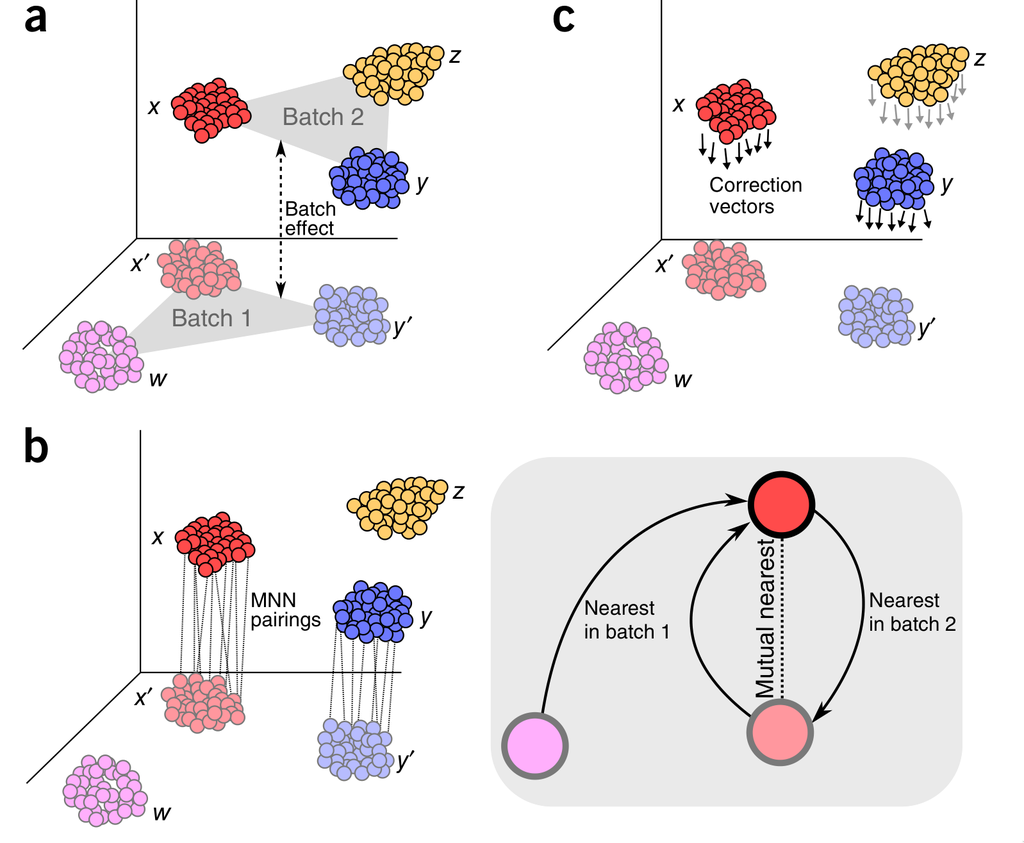

### Perform LSI embedding on separate datasets

Rather than integrating the normalized data matrix, as is typically done for scRNA-seq data, we’ll integrate the low-dimensional cell embeddings (the LSI coordinates) across the datasets using the `IntegrateEmbeddings` function. This is much better suited to scATAC-seq data, as we typically have a very sparse matrix with a large number of features. Note that this requires that we first compute an uncorrected LSI embedding using the merged dataset (as we did above).

```r
sample1 = FindTopFeatures(sample1, min.cutoff = 20)
sample1 = RunTFIDF(sample1)
sample1 = RunSVD(sample1)


sample2 = FindTopFeatures(sample2, min.cutoff = 20)
sample2 = RunTFIDF(sample2)
sample2 = RunSVD(sample2)

sample3 = FindTopFeatures(sample3, min.cutoff = 20)
sample3 = RunTFIDF(sample3)
sample3 = RunSVD(sample3)
```

### Identify integration anchors

```r
# find integration anchors
integration.anchors = FindIntegrationAnchors(
  object.list = list(sample1, sample2, sample3),
  anchor.features = rownames(sample1),
  reduction = "rlsi",
  dims = 2:30,
  verbose = F
)
```

### Integrate datasest

```r
# integrate LSI embeddings
integrated = IntegrateEmbeddings(
  anchorset = integration.anchors,
  reductions = combined[["lsi"]],
  new.reduction.name = "integrated_lsi",
  dims.to.integrate = 1:30,
  verbose = F
)
```

### Check integration results

Now that we have our final integration in the LSI space we can make another UMAP plot to see whether is was successful.

```r
# create a new UMAP using the integrated embeddings
integrated = RunUMAP(integrated, reduction = "integrated_lsi", dims = 2:30, verbose = F)
DimPlot(integrated, group.by = "dataset")
```

[output not shown]

Hopefully now all the samples are well integrated.

**P.S.**: The method we presented here is not the only one that can correct batch effects in single cell data. But one needs to pay attention when applying these tools to whether they were designed to work specifically with scRNA data. In case of the **anchor** based integration the method can be easily extended for use with scATAC data, but even in this case some adjustments were required. As was mentioned above partly due to extreme sparsity of the data we had to use reciprocal LSI for anchor identification instead of Canonical Correlation Analysis which is the original approach described for scRNA data. Another popular tool for data integration is [Harmony](https://www.nature.com/articles/s41592-019-0619-0), which is the default approach for dealing with batch effects when using [ArchR](https://www.archrproject.com/bookdown/batch-effect-correction-wtih-harmony.html), but it can also be used with a Seurat object.

## Session Info

It is good practice to print the so-called session info at the end of an R script, which prints all loaded libraries, their versions etc. This can be helpful for reproducibility and recapitulating which package versions have been used to produce the results obtained above.

[session information not shown]